Name : Ibtesam Shaikh

Student ID: 100812266

# Support Vector Machine VS Naive Bayes

### Import all the required Packages :

```python
import pandas as pd
import numpy as np
import matplotlib.pyplot as plt
%matplotlib inline
import seaborn as sns
from sklearn.preprocessing import RobustScaler
from sklearn.preprocessing import StandardScaler
from sklearn.model_selection import train_test_split
from sklearn.metrics import classification_report, confusion_matrix
from sklearn.metrics import accuracy_score
from sklearn.svm import SVC
from sklearn.naive_bayes import GaussianNB
from sklearn.model_selection import GridSearchCV
from sklearn.metrics import roc_curve
from sklearn.metrics import roc_auc_score
from sklearn.metrics import f1_score
from sklearn.metrics import auc
from sklearn.metrics import average_precision_score
from sklearn.metrics import plot_precision_recall_curve
```

### Read the CSV File in python:

```python
df=pd.read_csv("cancer.csv")
df
```

|  | id | Clump Thickness | UofCSize | UofCShape | Marginal Adhesion | SECSize | Bare Nuclei | Bland Chromatin | Normal Nucleoli | Mitoses | Class |
| --- | --- | --- | --- | --- | --- | --- | --- | --- | --- | --- | --- |
| 0 | 1000025 | 5 | 1 | 1 | 1 | 2 | 1 | 3 | 1 | 1 | 2 |
| 1 | 1002945 | 5 | 4 | 4 | 5 | 7 | 10 | 3 | 2 | 1 | 2 |
| 2 | 1015425 | 3 | 1 | 1 | 1 | 2 | 2 | 3 | 1 | 1 | 2 |
| 3 | 1016277 | 6 | 8 | 8 | 1 | 3 | 4 | 3 | 7 | 1 | 2 |
| 4 | 1017023 | 4 | 1 | 1 | 3 | 2 | 1 | 3 | 1 | 1 | 2 |
| ... | ... | ... | ... | ... | ... | ... | ... | ... | ... | ... | ... |
| 678 | 776715 | 3 | 1 | 1 | 1 | 3 | 2 | 1 | 1 | 1 | 2 |
| 679 | 841769 | 2 | 1 | 1 | 1 | 2 | 1 | 1 | 1 | 1 | 2 |
| 680 | 888820 | 5 | 10 | 10 | 3 | 7 | 3 | 8 | 10 | 2 | 4 |
| 681 | 897471 | 4 | 8 | 6 | 4 | 3 | 4 | 10 | 6 | 1 | 4 |
| 682 | 897471 | 4 | 8 | 8 | 5 | 4 | 5 | 10 | 4 | 1 | 4 |

683 rows × 11 columns

### Size of the Dataset:

```python
df.shape
```

```
(683, 11)
```

##### ✓ It contains 683 records and 11 variables.

### Drop the ID Column:

```python
df=df.drop('id',axis=1)
```

### First 5 records:

```python
df.head()
```

|  | Clump Thickness | UofCSize | UofCShape | Marginal Adhesion | SECSize | Bare Nuclei | Bland Chromatin | Normal Nucleoli | Mitoses | Class |
| --- | --- | --- | --- | --- | --- | --- | --- | --- | --- | --- |
| 0 | 5 | 1 | 1 | 1 | 2 | 1 | 3 | 1 | 1 | 2 |
| 1 | 5 | 4 | 4 | 5 | 7 | 10 | 3 | 2 | 1 | 2 |
| 2 | 3 | 1 | 1 | 1 | 2 | 2 | 3 | 1 | 1 | 2 |
| 3 | 6 | 8 | 8 | 1 | 3 | 4 | 3 | 7 | 1 | 2 |
| 4 | 4 | 1 | 1 | 3 | 2 | 1 | 3 | 1 | 1 | 2 |

##### ✓ The "id" column is deleted

### DataTypes of the Dataset:

```python
df.dtypes
```

```
Clump Thickness      int64
UofCSize             int64
UofCShape            int64
Marginal Adhesion    int64
SECSize              int64
Bare Nuclei          int64
Bland Chromatin      int64
Normal Nucleoli      int64
Mitoses              int64
Class                int64
dtype: object
```

##### ✓ All the Variables are integar Datatypes

### Check for Null Values :

```python
df.isnull().sum()
```

```
Clump Thickness      0
UofCSize             0
UofCShape            0
Marginal Adhesion    0
SECSize              0
Bare Nuclei          0
Bland Chromatin      0
Normal Nucleoli      0
Mitoses              0
Class                0
dtype: int64
```

##### ✓ There are no null values

### Check if the Data is Normal :

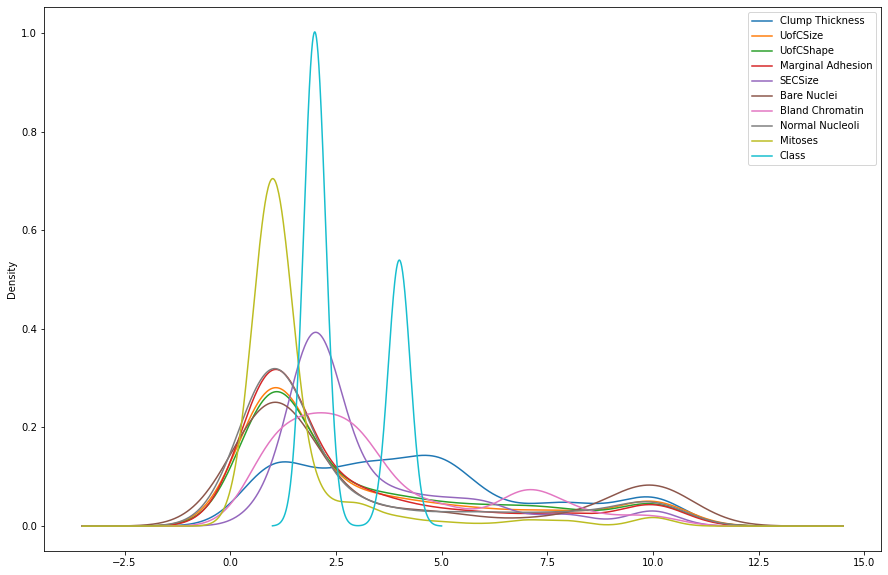

```python
df.plot.kde(figsize=(15,10))
```

##### ✓ The Data is not Normally distributed.

##### ✓ The Data is mostly Right skewed or positively skewed.

### Checking for Outliers :

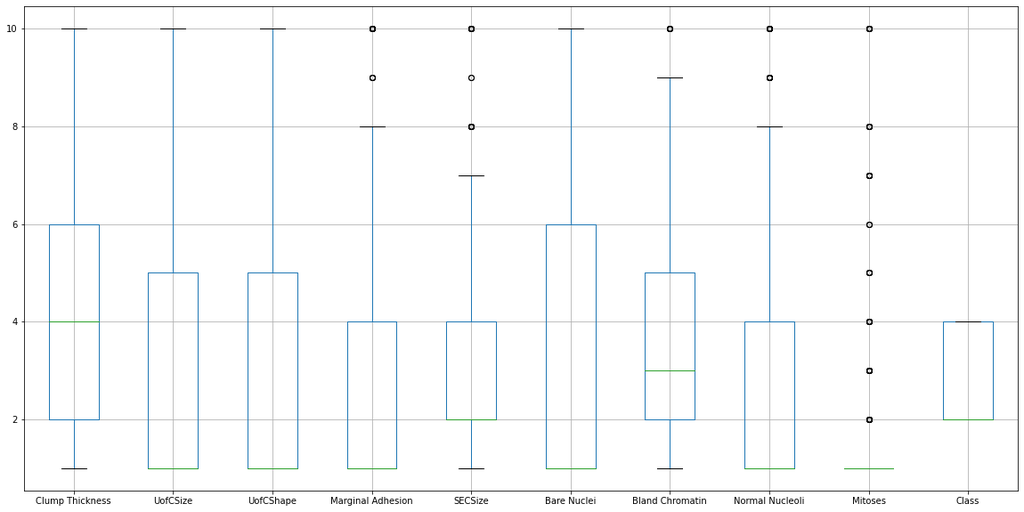

```python
df.boxplot(figsize=(20,10))
```

##### ✓ There are no outliers in “Clump Thickness” , “UofCShape” and ”UofCSize” Variables

##### ✓ There are few outliers in the “ Marginak Adhesion” Variable.

##### ✓ There are no outliers in “Bare Nuclei” Variable.

##### ✓ There are few outliers in “ SECSize”,”Bland Chromatin” and “Normal Nucleoli” Variables.

##### ✓ There are no outliers in “Class” Variable.

##### ✓ There are several outliers in “Mitoses” Variable

There are Quite a few outliers in the Data set as seen above and the data is right Skewed. Eliminating the outliers will disturb the data orientation and loss of insights as the data is distinct. Therefore the outliers need to be retained.

### Key Statistics:

```python
df.describe()
```

|  | Clump Thickness | UofCSize | UofCShape | Marginal Adhesion | SECSize | Bare Nuclei | Bland Chromatin | Normal Nucleoli | Mitoses | Class |
| --- | --- | --- | --- | --- | --- | --- | --- | --- | --- | --- |
| count | 683.000000 | 683.000000 | 683.000000 | 683.000000 | 683.000000 | 683.000000 | 683.000000 | 683.000000 | 683.000000 | 683.000000 |
| mean | 4.442167 | 3.150805 | 3.215227 | 2.830161 | 3.234261 | 3.544656 | 3.445095 | 2.869693 | 1.603221 | 2.699854 |
| std | 2.820761 | 3.065145 | 2.988581 | 2.864562 | 2.223085 | 3.643857 | 2.449697 | 3.052666 | 1.732674 | 0.954592 |
| min | 1.000000 | 1.000000 | 1.000000 | 1.000000 | 1.000000 | 1.000000 | 1.000000 | 1.000000 | 1.000000 | 2.000000 |
| 25% | 2.000000 | 1.000000 | 1.000000 | 1.000000 | 2.000000 | 1.000000 | 2.000000 | 1.000000 | 1.000000 | 2.000000 |
| 50% | 4.000000 | 1.000000 | 1.000000 | 1.000000 | 2.000000 | 1.000000 | 3.000000 | 1.000000 | 1.000000 | 2.000000 |
| 75% | 6.000000 | 5.000000 | 5.000000 | 4.000000 | 4.000000 | 6.000000 | 5.000000 | 4.000000 | 1.000000 | 4.000000 |
| max | 10.000000 | 10.000000 | 10.000000 | 10.000000 | 10.000000 | 10.000000 | 10.000000 | 10.000000 | 10.000000 | 4.000000 |

##### ✓ The Standard deviation of all the independent variables ranges from 1.73 to 3.6.

##### ✓ The Standard deviation of the Target variable is 0.95

##### ✓ The Minimum value of Independent variables is 1.

##### ✓ The Minimum value of Target variables is 2.

##### ✓ The Maximum value of Independent Variable is 10

##### ✓ The Maximum value of Target Variable is 4.

### Histogram of Class Variable :

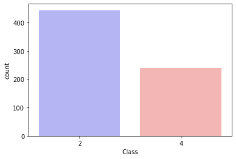

```python
sns.countplot(x="Class", data=df, palette="bwr")
plt.show()
```

##### ✓ The Malignant count is around 250 and Benign is more than 400.

### Pairplot

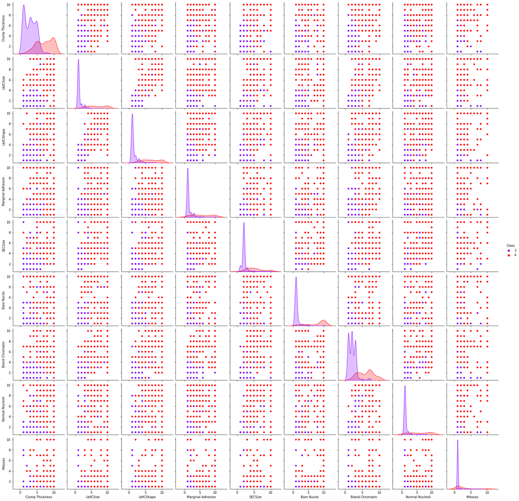

```python
plt.figure(figsize=(5,5))
sns.pairplot(df,hue = 'Class',palette= "rainbow")
```

### Correlation

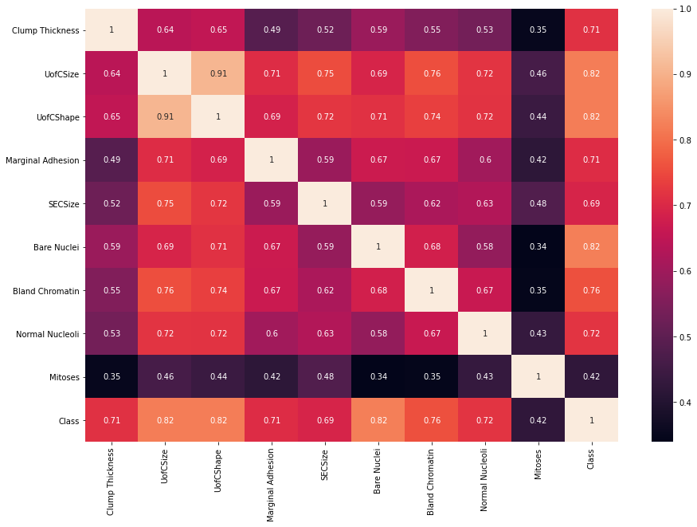

```python
plt.figure(figsize=(15,10))
sns.heatmap(df.corr(),annot=True)
```

### Standarization and Normalization:

### RobustScaler :

This Scaler removes the median and scales the data according to the quantile range (defaults to IQR: Interquartile Range). The IQR is the range between the 1st quartile (25th quantile) and the 3rd quartile (75th quantile).  
Centering and scaling happen independently on each feature by computing the relevant statistics on the samples in the training set. Median and interquartile range are then stored to be used on later data using the transform method.

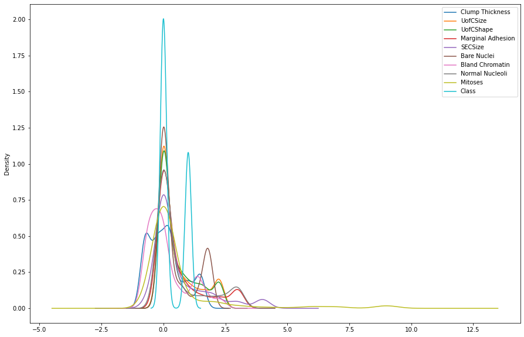

```python
Rs = RobustScaler(with_scaling=True)
data_tf = Rs.fit_transform(df)
df_a = pd.DataFrame(data_tf,columns=['Clump Thickness', 'UofCSize', 'UofCShape', 'Marginal Adhesion',
       'SECSize', 'Bare Nuclei', 'Bland Chromatin', 'Normal Nucleoli',
       'Mitoses', 'Class'])
df_a.plot.kde(figsize=(15,10))
```

##### ✓ Robust Scaler is used to Normalize the data in the presence of the outliers.

# Modelling :

### Support vector Machine:

```python
x = df_a.drop('Class',axis=1).to_numpy()
y = df_a['Class'].to_numpy()
from sklearn.model_selection import train_test_split
x_train,x_test,y_train,y_test=train_test_split(x,y,test_size=0.3,stratify=y,random_state=100)
```

```python
sc = StandardScaler()
x_train2 = sc.fit_transform(x_train)
x_test2 = sc.transform(x_test)
```

#### GridSearchCV():

##### ✓ Using GridSearchCV() lets find out the best parameters for the model

```python
params_grid = {'C': [0.001, 0.01, 0.1, 1, 10, 100],
          'gamma': [0.0001, 0.001, 0.01, 0.1],
          'kernel':['linear','rbf','sigmoid','poly'] }
```

```python
grid_clf = GridSearchCV(SVC(class_weight='balanced'), params_grid,refit=True,verbose=2)
```

```python
model1=grid_clf.fit(x_train2,y_train)
```

[output not shown]

```
[Parallel(n_jobs=1)]: Using backend SequentialBackend with 1 concurrent workers.
[Parallel(n_jobs=1)]: Done   1 out of   1 | elapsed:    0.0s remaining:    0.0s
```

[output not shown]

[output cut: 889 more lines]

[output not shown]

```
[Parallel(n_jobs=1)]: Done 480 out of 480 | elapsed:    4.2s finished
```

```python
a=grid_clf.best_params_['C']
a
```

```
1
```

```python
b=grid_clf.best_params_['gamma']
b
```

```
0.1
```

```python
c=grid_clf.best_params_['kernel']
c
```

```
'sigmoid'
```

```python
print("Best Parameters:")
print('C: {0:0.2f}'.format(a))
print('gamma: {0:0.2f}'.format(b))
print('kernel:', c)
```

```
Best Parameters:
C: 1.00
gamma: 0.10
kernel: sigmoid
```

### SVM Model using the best parameters

```python
Model=SVC(kernel=c,C=a,gamma=b,probability=True)
```

```python
Model.fit(x_train2,y_train)
predict = Model.predict(x_test2)
target_names=['benign','malignant']
print(confusion_matrix(y_test,predict))
print(classification_report(y_test,predict,target_names=target_names))
```

```
[[128   5]
 [  5  67]]
              precision    recall  f1-score   support

      benign       0.96      0.96      0.96       133
   malignant       0.93      0.93      0.93        72

    accuracy                           0.95       205
   macro avg       0.95      0.95      0.95       205
weighted avg       0.95      0.95      0.95       205
```

```python
print("Accuracy")

print(accuracy_score(y_test,predict))
```

```
Accuracy
0.9512195121951219
```

### Naive Bayes Model

```python
Model1=GaussianNB()
```

```python
Model1.fit(x_train2,y_train)
predictions = Model1.predict(x_test2)
target_names=['benign','malignant']
print(confusion_matrix(y_test,predictions))
print(classification_report(y_test,predictions,target_names=target_names))
```

```
[[127   6]
 [  2  70]]
              precision    recall  f1-score   support

      benign       0.98      0.95      0.97       133
   malignant       0.92      0.97      0.95        72

    accuracy                           0.96       205
   macro avg       0.95      0.96      0.96       205
weighted avg       0.96      0.96      0.96       205
```

```python
print("Accuracy")

print(accuracy_score(y_test,predictions))
```

```
Accuracy
0.9609756097560975
```

# TEST SIZE = 0.2 Variant

```python
x = df_a.drop('Class',axis=1).to_numpy()
y = df_a['Class'].to_numpy()
from sklearn.model_selection import train_test_split
x_train1,x_test1,y_train1,y_test1=train_test_split(x,y,test_size=0.2,stratify=y,random_state=100)
sc = StandardScaler()
x_train3 = sc.fit_transform(x_train1)
x_test3 = sc.transform(x_test1)
```

```python
params_grid = {'C': [0.001, 0.01, 0.1, 1, 10, 100],
          'gamma': [0.0001, 0.001, 0.01, 0.1],
          'kernel':['linear','rbf','sigmoid','poly'] }
```

```python
grid = GridSearchCV(SVC(class_weight='balanced'), params_grid,refit=True,verbose=2)
```

```python
model2=grid.fit(x_train3,y_train1)
```

[output not shown]

```
[Parallel(n_jobs=1)]: Using backend SequentialBackend with 1 concurrent workers.
[Parallel(n_jobs=1)]: Done   1 out of   1 | elapsed:    0.0s remaining:    0.0s
```

[output not shown]

[output cut: 879 more lines]

[output not shown]

```
[Parallel(n_jobs=1)]: Done 480 out of 480 | elapsed:    5.1s finished
```

```python
grid.best_params_['C']
```

```
10
```

```python
grid.best_params_['gamma']
```

```
0.0001
```

```python
grid.best_params_['kernel']
```

```
'linear'
```

```python
for name,method in [('SVM', SVC(kernel='linear',C=10,gamma=0.0001,random_state=100)),
                    ('Naive Bayes',GaussianNB())]:
    method.fit(x_train3,y_train1)
    predict11 = method.predict(x_test3)
    target_names=['Benign','Malignant']
    print('\nEstimator: {}'.format(name))
    print(confusion_matrix(y_test1,predict11))
    print(classification_report(y_test1,predict11,target_names=target_names))
```

```
Estimator: SVM
[[89  0]
 [ 2 46]]
              precision    recall  f1-score   support

      Benign       0.98      1.00      0.99        89
   Malignant       1.00      0.96      0.98        48

    accuracy                           0.99       137
   macro avg       0.99      0.98      0.98       137
weighted avg       0.99      0.99      0.99       137


Estimator: Naive Bayes
[[86  3]
 [ 1 47]]
              precision    recall  f1-score   support

      Benign       0.99      0.97      0.98        89
   Malignant       0.94      0.98      0.96        48

    accuracy                           0.97       137
   macro avg       0.96      0.97      0.97       137
weighted avg       0.97      0.97      0.97       137
```

# Comparision of Confusion Matrixes

```python
cm_lr = confusion_matrix(y_test,predict)
```

```python
cm_mlp=confusion_matrix(y_test,predictions)
```

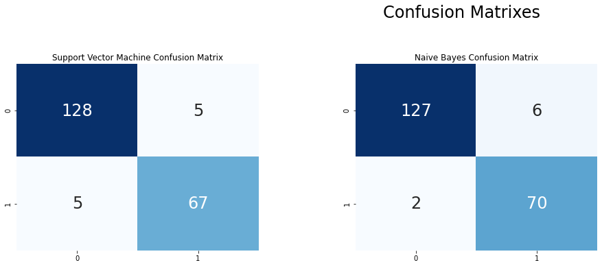

```python
plt.figure(figsize=(24,12))

plt.suptitle("Confusion Matrixes",fontsize=24)
plt.subplots_adjust(wspace = 0.4, hspace= 0.4)


plt.subplot(2,3,1)
plt.title("Support Vector Machine Confusion Matrix")
sns.heatmap(cm_lr,annot=True,cmap="Blues",fmt="d",cbar=False, annot_kws={"size": 24})

plt.subplot(2,3,2)
plt.title("Naive Bayes Confusion Matrix")
sns.heatmap(cm_mlp,annot=True,cmap="Blues",fmt="d",cbar=False, annot_kws={"size": 24})
```

# Comparision of Accuracy

[output not shown]

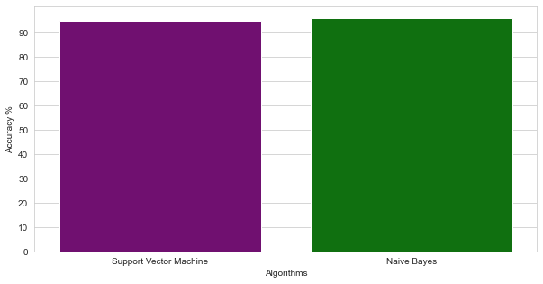

```python
colors = ["purple", "green"]

sns.set_style("whitegrid")
plt.figure(figsize=(10,5))
plt.yticks(np.arange(0,100,10))
plt.ylabel("Accuracy %")
plt.xlabel("Algorithms")
x=["Support Vector Machine","Naive Bayes"]
y=[95,96]
sns.barplot(x,y, palette=colors)
plt.show()
```

# AUC-ROC Curve:

##### predict probabilities:

```python
pred_prob2 = Model1.predict_proba(x_test2)
```

```python
pred_prob1 = Model.predict_proba(x_test2)
```

##### keep probabilities for the positive outcome only

```python
pred_prob1 = pred_prob1[:, 1]
pred_prob2 = pred_prob2[:, 1]
```

##### Calculate the auc scores and print them

```python
ns_auc = roc_auc_score(y_test, pred_prob1)
lr_auc = roc_auc_score(y_test, pred_prob2)
```

```python
print('Support Vector Machine: ROC AUC=%.3f' % (ns_auc))
print('Naive Bayees: ROC AUC=%.3f' % (lr_auc))
```

```
Support Vector Machine: ROC AUC=0.984
Naive Bayees: ROC AUC=0.985
```

##### Calculate ROC Curve

```python
ns_fpr, ns_tpr, _ = roc_curve(y_test, pred_prob1)
lr_fpr, lr_tpr, _ = roc_curve(y_test, pred_prob2)
```

##### When True Positive Rate = False Positive Rate

```python
random_probs = [0 for i in range(len(y_test))]
p_fpr, p_tpr, _ = roc_curve(y_test, random_probs, pos_label=1)
```

##### Plot the roc curve for the model

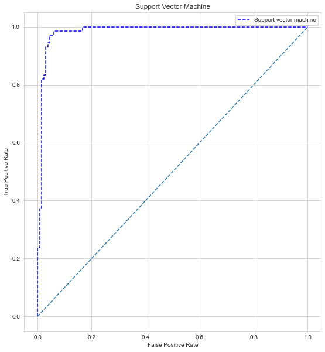

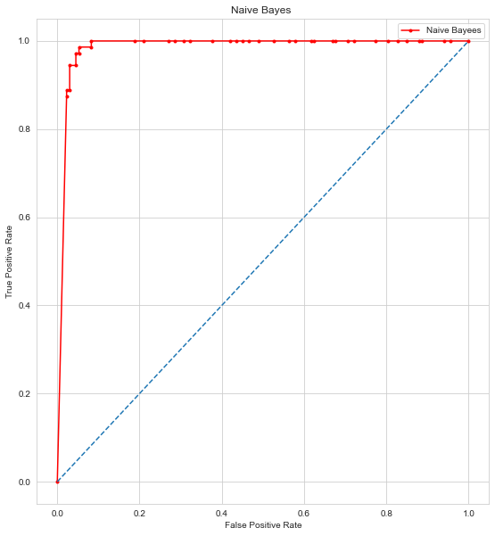

```python
plt.figure(figsize=(20,10))
plt.subplot(1,2,1)
plt.title("Support Vector Machine")
plt.plot(ns_fpr, ns_tpr, linestyle='--', label='Support vector machine',color='blue')
plt.plot(p_fpr, p_tpr, linestyle='--' )
plt.xlabel('False Positive Rate')
plt.ylabel('True Positive Rate')
plt.legend()
plt.show()

plt.figure(figsize=(20,10))
plt.subplot(1,2,2)
plt.title("Naive Bayes ")
plt.plot(lr_fpr, lr_tpr, marker='.', label='Naive Bayees',color='Red')
plt.plot(p_fpr, p_tpr, linestyle='--' )
plt.xlabel('False Positive Rate')
plt.ylabel('True Positive Rate')
plt.legend()
plt.show()
```

### Precision VS Recall

```python
average_precision = average_precision_score(y_test, predict)
print('Average precision-recall score Support Vector Machine: {0:0.2f}'.format(
      average_precision))
```

```
Average precision-recall score Support Vector Machine: 0.89
```

```python
average_precision1 = average_precision_score(y_test, predictions)
print('Average precision-recall score Naive Bayees: {0:0.2f}'.format(
      average_precision1))
```

```
Average precision-recall score Naive Bayees: 0.91
```

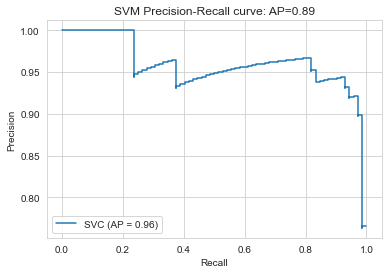

```python
disp = plot_precision_recall_curve(Model, x_test2, y_test)
disp.ax_.set_title('SVM Precision-Recall curve: '
                   'AP={0:0.2f}'.format(average_precision))
```

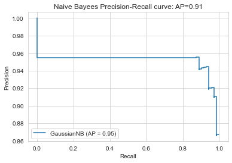

```python
plt.figure(figsize=(20,10))
disp = plot_precision_recall_curve(Model1, x_test2, y_test)
disp.ax_.set_title('Naive Bayees Precision-Recall curve: '
                   'AP={0:0.2f}'.format(average_precision1))
```